# Breast Cancer Final Work

Names: Julia Monfort and Elena Mª García

Subject: Models for decision-making

Course: 3º Data Science

## Objective

In this case we want to achive something related to the Sustainable Development Goals (SDG or ODS in spanish) so we selected the good health and well-being section and decided to make it about the breast cancer.

We will use algorithms of machine learning in python to solve this problem with logistic regression.

The breast_cancer data set we selected contains patient records collected by the German Breast Cancer Study Group (GBSG) of 686 patients with complete data for the prognostic variables.

We want to make a prediction model so that we can know if a person will have a breast cancer recurrence or not.

### 1. Import libraries

Firstly we import all the libraries we will use to do the model.

```python
import pandas as pd
import numpy as np
import seaborn as sns
from matplotlib import pyplot as plt
from sklearn.metrics import confusion_matrix
from sklearn.metrics import classification_report
from sklearn.model_selection import train_test_split
from sklearn.preprocessing import StandardScaler
from sklearn.linear_model import LogisticRegression
from sklearn.ensemble import RandomForestClassifier
from sklearn.tree import DecisionTreeClassifier
```

### 2. Read the dataframe

```python
breast_cancer = pd.read_csv("breast_cancer.csv")
breast_cancer
```

|  | Unnamed: 0 | pid | age | meno | size | grade | nodes | pgr | er | hormon | rfstime | status |
| --- | --- | --- | --- | --- | --- | --- | --- | --- | --- | --- | --- | --- |
| 0 | 1 | 132 | 49 | 0 | 18 | 2 | 2 | 0 | 0 | 0 | 1838 | 0 |
| 1 | 2 | 1575 | 55 | 1 | 20 | 3 | 16 | 0 | 0 | 0 | 403 | 1 |
| 2 | 3 | 1140 | 56 | 1 | 40 | 3 | 3 | 0 | 0 | 0 | 1603 | 0 |
| 3 | 4 | 769 | 45 | 0 | 25 | 3 | 1 | 0 | 4 | 0 | 177 | 0 |
| 4 | 5 | 130 | 65 | 1 | 30 | 2 | 5 | 0 | 36 | 1 | 1855 | 0 |
| ... | ... | ... | ... | ... | ... | ... | ... | ... | ... | ... | ... | ... |
| 681 | 682 | 586 | 51 | 0 | 30 | 3 | 2 | 1152 | 38 | 1 | 1760 | 0 |
| 682 | 683 | 1273 | 64 | 1 | 26 | 2 | 2 | 1356 | 1144 | 1 | 1152 | 0 |
| 683 | 684 | 1525 | 57 | 1 | 35 | 3 | 1 | 1490 | 209 | 1 | 1342 | 0 |
| 684 | 685 | 736 | 44 | 0 | 21 | 2 | 3 | 1600 | 70 | 0 | 629 | 0 |
| 685 | 686 | 894 | 80 | 1 | 7 | 2 | 7 | 2380 | 972 | 1 | 758 | 0 |

686 rows × 12 columns

Now we will explain what each column is:

- Unnamed: 0 is the id column.
- pid is the column with the patient id in the hospital or institution.
- age is obiusly the age of the patient.
- meno says the patient menopausal status (0: premenopause, 1: postmenopause).
- size is the tumor size in milimeters.
- grade is the tumor grade.
- nodes is the number of positive lymph nodes.
- pgr are the progesterone receptors (fmol/l).
- er are the estrogen receptors (fmol/l).
- hormon tells us if the patient has hormonal therapy (0: no, 1: yes).
- rfstime is the amount of time without recurrence until there is recurrence or death.
- status is the column that tells us if the patient id alive without recurrence: 0, or there is recurrence or death: 1.

It is obvious that the first column does not give us any information, so we will drop it from the dataframe so that we can work more easily, and also the column with the patient id (pid) will not be necassary for the same reason.

```python
breast_cancer = breast_cancer.drop(["Unnamed: 0", "pid"], axis = 1)
breast_cancer
```

|  | age | meno | size | grade | nodes | pgr | er | hormon | rfstime | status |
| --- | --- | --- | --- | --- | --- | --- | --- | --- | --- | --- |
| 0 | 49 | 0 | 18 | 2 | 2 | 0 | 0 | 0 | 1838 | 0 |
| 1 | 55 | 1 | 20 | 3 | 16 | 0 | 0 | 0 | 403 | 1 |
| 2 | 56 | 1 | 40 | 3 | 3 | 0 | 0 | 0 | 1603 | 0 |
| 3 | 45 | 0 | 25 | 3 | 1 | 0 | 4 | 0 | 177 | 0 |
| 4 | 65 | 1 | 30 | 2 | 5 | 0 | 36 | 1 | 1855 | 0 |
| ... | ... | ... | ... | ... | ... | ... | ... | ... | ... | ... |
| 681 | 51 | 0 | 30 | 3 | 2 | 1152 | 38 | 1 | 1760 | 0 |
| 682 | 64 | 1 | 26 | 2 | 2 | 1356 | 1144 | 1 | 1152 | 0 |
| 683 | 57 | 1 | 35 | 3 | 1 | 1490 | 209 | 1 | 1342 | 0 |
| 684 | 44 | 0 | 21 | 2 | 3 | 1600 | 70 | 0 | 629 | 0 |
| 685 | 80 | 1 | 7 | 2 | 7 | 2380 | 972 | 1 | 758 | 0 |

686 rows × 10 columns

Now we look for null values in the dataset in case we have to do something about them.

```python
breast_cancer.info()
```

```
<class 'pandas.core.frame.DataFrame'>
RangeIndex: 686 entries, 0 to 685
Data columns (total 10 columns):
 #   Column   Non-Null Count  Dtype
---  ------   --------------  -----
 0   age      686 non-null    int64
 1   meno     686 non-null    int64
 2   size     686 non-null    int64
 3   grade    686 non-null    int64
 4   nodes    686 non-null    int64
 5   pgr      686 non-null    int64
 6   er       686 non-null    int64
 7   hormon   686 non-null    int64
 8   rfstime  686 non-null    int64
 9   status   686 non-null    int64
dtypes: int64(10)
memory usage: 53.7 KB
```

As we can see, there isn't any null value.

We will describe the dataset to see it in more depth.

```python
breast_cancer.describe()
```

|  | age | meno | size | grade | nodes | pgr | er | hormon | rfstime | status |
| --- | --- | --- | --- | --- | --- | --- | --- | --- | --- | --- |
| count | 686.000000 | 686.000000 | 686.000000 | 686.000000 | 686.000000 | 686.000000 | 686.000000 | 686.000000 | 686.000000 | 686.000000 |
| mean | 53.052478 | 0.577259 | 29.329446 | 2.116618 | 5.010204 | 109.995627 | 96.252187 | 0.358601 | 1124.489796 | 0.435860 |
| std | 10.120739 | 0.494355 | 14.296217 | 0.582808 | 5.475483 | 202.331552 | 153.083963 | 0.479940 | 642.791948 | 0.496231 |
| min | 21.000000 | 0.000000 | 3.000000 | 1.000000 | 1.000000 | 0.000000 | 0.000000 | 0.000000 | 8.000000 | 0.000000 |
| 25% | 46.000000 | 0.000000 | 20.000000 | 2.000000 | 1.000000 | 7.000000 | 8.000000 | 0.000000 | 567.750000 | 0.000000 |
| 50% | 53.000000 | 1.000000 | 25.000000 | 2.000000 | 3.000000 | 32.500000 | 36.000000 | 0.000000 | 1084.000000 | 0.000000 |
| 75% | 61.000000 | 1.000000 | 35.000000 | 2.000000 | 7.000000 | 131.750000 | 114.000000 | 1.000000 | 1684.750000 | 1.000000 |
| max | 80.000000 | 1.000000 | 120.000000 | 3.000000 | 51.000000 | 2380.000000 | 1144.000000 | 1.000000 | 2659.000000 | 1.000000 |

### 3. Data visualization

Firstly we plot the frequency of each status.

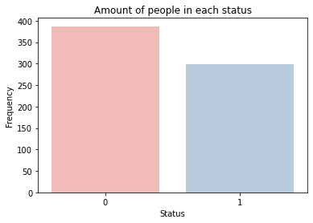

```python
sns.countplot(x="status", data=breast_cancer, palette="Pastel1")
plt.xlabel('Status')
plt.ylabel('Frequency')
plt.title("Amount of people in each status")
plt.show()
```

There is a bigger amount of people without recurrence than people that have had it again or have died because of it.

Now we will show the distribution of the patients in age.

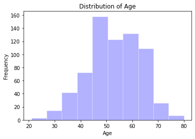

```python
plt.hist(breast_cancer['age'], bins=10, edgecolor='white', color="blue", alpha=0.3)
plt.xlabel('Age')
plt.ylabel('Frequency')
plt.title('Distribution of Age')
plt.show()
```

In this plot we see that there is a bigger amount of patients between the ages of 45 and 70.

The correlation plot will guide us so we can know the better variables to use for the prediction model.

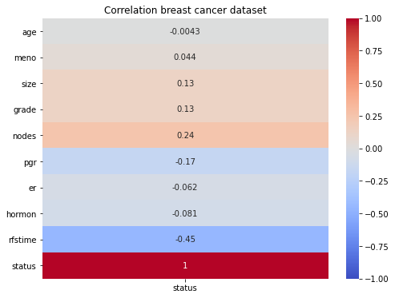

```python
plt.figure(figsize=(8,6))
sns.heatmap(breast_cancer.corr()[['status']], vmin = -1, vmax = +1, annot = True, cmap = 'coolwarm')
plt.title("Correlation breast cancer dataset")
plt.show()
```

With this plot we can see that the variables that show the most correlation are:

- nodes
- rfstime
- pgr

This variables will be the ones we use to do the prediction model.

### 4. Let's Model!

We divide in X and y the different variables. Using the ones we said before as independent variables and status as the one we want to predict.

```python
X =np.asarray(breast_cancer[["nodes", "rfstime", "pgr"]])
y =np.asarray(breast_cancer['status'])
```

Normalize the values of X

```python
X = StandardScaler().fit(X).transform(X)
```

Divide in train and test with a test size of 30 %.

```python
X_train, X_test, y_train, y_test = train_test_split(X, y, test_size=0.3, random_state=42)

print("Train set: ", X_train.shape, y_train.shape)
print("Test set: ", X_test.shape, y_test.shape)
```

```
Train set:  (480, 3) (480,)
Test set:  (206, 3) (206,)
```

Create the model, train it and predict the values with X_test.

```python
lr = LogisticRegression()
lr.fit(X_train, y_train)

lr_pred = lr.predict(X_test)
```

Do a confusion matrix to know if the predicted values are correct.

```python
cm = confusion_matrix(y_test, lr_pred)
cm_setup = pd.DataFrame(data=cm)
```

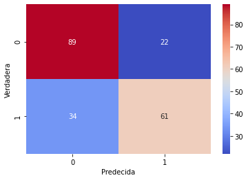

```python
sns.heatmap(cm_setup, annot = True, cmap="coolwarm")
plt.ylabel('Verdadera')
plt.xlabel('Predecida')
plt.show()
```

- True positives: 61.
- True negatives: 89.
- False positives: 22.
- False negatives: 34.

```python
print(classification_report(y_test, lr_pred))
```

```
              precision    recall  f1-score   support

           0       0.72      0.80      0.76       111
           1       0.73      0.64      0.69        95

    accuracy                           0.73       206
   macro avg       0.73      0.72      0.72       206
weighted avg       0.73      0.73      0.73       206
```

```python
print("The score for this model is: ",lr.score(X, y))
```

```
The score for this model is:  0.7288629737609329
```

With all of this the conclusion we can make is that the model has an accuracy of 0.73, so the model is pretty good. But, because there are 34 false negatives it is a risky model and we should take that into consideration in the future.

Because of this the decision we made was to try and do a decision tree classifier and a random forest to try and make a better model for decision-making.

### 5. Decision Tree Classifier

First, the decision tree to see if it makes a difference with the logistic regression.

```
Confusion matrix:
```

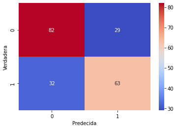

```
Classification report:

              precision    recall  f1-score   support

           0       0.72      0.74      0.73       111
           1       0.68      0.66      0.67        95

    accuracy                           0.70       206
   macro avg       0.70      0.70      0.70       206
weighted avg       0.70      0.70      0.70       206



The score for this model is:  0.7361516034985423
```

```python
dt = DecisionTreeClassifier(criterion='gini',
                                            min_samples_split=20,
                                            min_samples_leaf=5,
                                            max_depth = 3)

dt.fit(X_train,y_train)

dt_pred = dt.predict(X_test)

print('Confusion matrix:')
cm_dt = confusion_matrix(y_test, dt_pred)
cm_dt_setup = pd.DataFrame(data=cm_dt)
sns.heatmap(cm_dt_setup, annot = True, cmap="coolwarm")
plt.ylabel('Verdadera')
plt.xlabel('Predecida')
plt.show()
print('\n')
print('Classification report:\n')
print(classification_report(y_test, dt_pred))
print('\n')
print("The score for this model is: ",dt.score(X, y))
```

With the decision tree classifier it's seen that the amount of false negatives is a little lower, but in contrast the false positives goes up with bigger difference. For this reason we don't think is better than the logistic regression model.

### 6. Random Forest

Now for the Random Forest firstly we will try different parameters to select the best for the model. After selecting the best of them we will train the final model of random forest and look if the results are better than the other 2.

```python
from sklearn.model_selection import GridSearchCV
rf = RandomForestClassifier()

param_grid = {"max_depth": range(6, 13), "n_estimators": [10, 50, 100, 200]}

grid_search = GridSearchCV(rf, param_grid=param_grid, cv=4)
grid_search.fit(X_train, y_train)

means = grid_search.cv_results_["mean_test_score"]
stds = grid_search.cv_results_["std_test_score"]
params = grid_search.cv_results_['params']

for mean, std, pms in zip(means, stds, params):
    print("Precisión Media  {:.2f} +/- {:.2f} con parametros {}".format(mean*100, std*100, pms))
print("Los mejores parámetros han sido: {}".format(grid_search.best_params_))
```

```
Precisión Media  73.33 +/- 4.04 con parametros {'max_depth': 6, 'n_estimators': 10}
Precisión Media  71.88 +/- 3.79 con parametros {'max_depth': 6, 'n_estimators': 50}
Precisión Media  73.96 +/- 4.58 con parametros {'max_depth': 6, 'n_estimators': 100}
Precisión Media  72.92 +/- 2.80 con parametros {'max_depth': 6, 'n_estimators': 200}
Precisión Media  72.29 +/- 4.14 con parametros {'max_depth': 7, 'n_estimators': 10}
Precisión Media  73.75 +/- 4.43 con parametros {'max_depth': 7, 'n_estimators': 50}
Precisión Media  74.17 +/- 4.82 con parametros {'max_depth': 7, 'n_estimators': 100}
Precisión Media  75.00 +/- 3.12 con parametros {'max_depth': 7, 'n_estimators': 200}
Precisión Media  72.29 +/- 3.70 con parametros {'max_depth': 8, 'n_estimators': 10}
Precisión Media  72.50 +/- 3.86 con parametros {'max_depth': 8, 'n_estimators': 50}
Precisión Media  73.12 +/- 4.14 con parametros {'max_depth': 8, 'n_estimators': 100}
Precisión Media  72.92 +/- 3.46 con parametros {'max_depth': 8, 'n_estimators': 200}
Precisión Media  72.08 +/- 2.98 con parametros {'max_depth': 9, 'n_estimators': 10}
Precisión Media  73.33 +/- 3.82 con parametros {'max_depth': 9, 'n_estimators': 50}
Precisión Media  72.08 +/- 3.97 con parametros {'max_depth': 9, 'n_estimators': 100}
Precisión Media  74.58 +/- 2.08 con parametros {'max_depth': 9, 'n_estimators': 200}
Precisión Media  71.46 +/- 2.79 con parametros {'max_depth': 10, 'n_estimators': 10}
Precisión Media  72.29 +/- 4.06 con parametros {'max_depth': 10, 'n_estimators': 50}
Precisión Media  72.92 +/- 5.29 con parametros {'max_depth': 10, 'n_estimators': 100}
Precisión Media  72.92 +/- 4.27 con parametros {'max_depth': 10, 'n_estimators': 200}
Precisión Media  71.46 +/- 5.41 con parametros {'max_depth': 11, 'n_estimators': 10}
Precisión Media  74.58 +/- 4.91 con parametros {'max_depth': 11, 'n_estimators': 50}
Precisión Media  73.12 +/- 3.08 con parametros {'max_depth': 11, 'n_estimators': 100}
Precisión Media  73.12 +/- 4.62 con parametros {'max_depth': 11, 'n_estimators': 200}
Precisión Media  71.25 +/- 2.92 con parametros {'max_depth': 12, 'n_estimators': 10}
Precisión Media  73.75 +/- 3.15 con parametros {'max_depth': 12, 'n_estimators': 50}
Precisión Media  72.92 +/- 3.84 con parametros {'max_depth': 12, 'n_estimators': 100}
Precisión Media  72.92 +/- 3.84 con parametros {'max_depth': 12, 'n_estimators': 200}
Los mejores parámetros han sido: {'max_depth': 7, 'n_estimators': 200}
```

The model selects as the best parameters max_depth: 7 and n_estimators: 200. We will use them to train the final Random Forest model.

```
Confusion matrix:
```

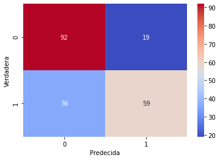

```
Classification report:

              precision    recall  f1-score   support

           0       0.72      0.83      0.77       111
           1       0.76      0.62      0.68        95

    accuracy                           0.73       206
   macro avg       0.74      0.72      0.73       206
weighted avg       0.74      0.73      0.73       206



The score for this model is:  0.8527696793002916
```

```python
rf = RandomForestClassifier(max_depth=7,
                           n_estimators=200,
                           random_state=42)

rf.fit(X_train,y_train)

rf_pred = rf.predict(X_test)

print('Confusion matrix:')
cm_dt = confusion_matrix(y_test, rf_pred)
cm_dt_setup = pd.DataFrame(data=cm_dt)
sns.heatmap(cm_dt_setup, annot = True, cmap="coolwarm")
plt.ylabel('Verdadera')
plt.xlabel('Predecida')
plt.show()
print('\n')
print('Classification report:\n')
print(classification_report(y_test, rf_pred))
print('\n')
print("The score for this model is: ",rf.score(X, y))
```

We see that there are more True negatives, but the false negatives also go up in number so we can't say that the model solves the principal problem of the logistic regression model. Even in that case we see that the model score is bigger than the other 2. In the other 2 cases it was around 0.73, but in this one is 0.85.

### 7. Predictions

Now we will make predictions with 2 different samples to know what would happen if someone had those characteristics.

There will be a comparation between the random forest, that had the best score of all the models, and the logistic regression model, that is the first one we did.

```python
sample_1 = np.array([8, 500, 1000]).reshape(1, -1)
sample_2 = np.array([2, 70, 2000]).reshape(1, -1)

rf_1=rf.predict(sample_1)
rf_2=rf.predict(sample_2)
lr_1=lr.predict(sample_1)
lr_2=lr.predict(sample_2)

print("Sample 1:\n")
print("The prediction with random forest for the sample 1 is: ",rf_1[0])
print("The prediction with logistic regression for the sample 1 is: ",lr_1[0])
print("\nSample 2:\n")
print("The prediction with random forest for the sample 2 is: ",rf_2[0])
print("The prediction with logistic regression for the sample 2 is: ",lr_2[0])
```

```
Sample 1:

The prediction with random forest for the sample 1 is:  0
The prediction with logistic regression for the sample 1 is:  0

Sample 2:

The prediction with random forest for the sample 2 is:  0
The prediction with logistic regression for the sample 2 is:  0
```

With this we see that there is a consensus between the 2 models, with this samples the patients supposedly won't have a recurrence in their breast cancer.